# Project: Investigating TMDB Movie Dataset

- Introduction
- Data Wrangling
  - General Properties
  - Data Cleaning
    - Dropping Unneeded Properties
    - Adjusting Values
    - Splitting Multi Value Properties
    - Refining The Dataset
- Exploratory Data Analysis
- Conclusions

## Introduction

The TMDB movie dataset was selected for investigating given the author's interest in The film industry. There are some factors influencing the success or failure of a movie. In this project the author analyzes the dataset to find some successful features for movies answering the questions below:

- Which companies invested the most in film production from 2000 to 2015?
- Which movie genres were most produced from 2000 to 2015?
- What were the genres of the high revenue movies from 2000 to 2015?

```python
# Importing packages that help with dataset analysis
import pandas as pd
import numpy as np
import matplotlib.pyplot as plt

%matplotlib inline
```

## Data Wrangling

### General Properties

```python
# Loading the dataset and print out a few lines.
df = pd.read_csv('tmdb-movies.csv')
df.head()
```

|  | id | imdb_id | popularity | budget | revenue | original_title | cast | homepage | director | tagline | ... | overview | runtime | genres | production_companies | release_date | vote_count | vote_average | release_year | budget_adj | revenue_adj |
| --- | --- | --- | --- | --- | --- | --- | --- | --- | --- | --- | --- | --- | --- | --- | --- | --- | --- | --- | --- | --- | --- |
| 0 | 135397 | tt0369610 | 32.99 | 150000000 | 1513528810 | Jurassic World | Chris Pratt\|Bryce Dallas Howard\|Irrfan Khan\|Vi... | http://www.jurassicworld.com/ | Colin Trevorrow | The park is open. | ... | Twenty-two years after the events of Jurassic ... | 124 | Action\|Adventure\|Science Fiction\|Thriller | Universal Studios\|Amblin Entertainment\|Legenda... | 6/9/15 | 5562 | 6.50 | 2015 | 137999939.28 | 1392445892.52 |
| 1 | 76341 | tt1392190 | 28.42 | 150000000 | 378436354 | Mad Max: Fury Road | Tom Hardy\|Charlize Theron\|Hugh Keays-Byrne\|Nic... | http://www.madmaxmovie.com/ | George Miller | What a Lovely Day. | ... | An apocalyptic story set in the furthest reach... | 120 | Action\|Adventure\|Science Fiction\|Thriller | Village Roadshow Pictures\|Kennedy Miller Produ... | 5/13/15 | 6185 | 7.10 | 2015 | 137999939.28 | 348161292.49 |
| 2 | 262500 | tt2908446 | 13.11 | 110000000 | 295238201 | Insurgent | Shailene Woodley\|Theo James\|Kate Winslet\|Ansel... | http://www.thedivergentseries.movie/#insurgent | Robert Schwentke | One Choice Can Destroy You | ... | Beatrice Prior must confront her inner demons ... | 119 | Adventure\|Science Fiction\|Thriller | Summit Entertainment\|Mandeville Films\|Red Wago... | 3/18/15 | 2480 | 6.30 | 2015 | 101199955.47 | 271619025.41 |
| 3 | 140607 | tt2488496 | 11.17 | 200000000 | 2068178225 | Star Wars: The Force Awakens | Harrison Ford\|Mark Hamill\|Carrie Fisher\|Adam D... | http://www.starwars.com/films/star-wars-episod... | J.J. Abrams | Every generation has a story. | ... | Thirty years after defeating the Galactic Empi... | 136 | Action\|Adventure\|Science Fiction\|Fantasy | Lucasfilm\|Truenorth Productions\|Bad Robot | 12/15/15 | 5292 | 7.50 | 2015 | 183999919.04 | 1902723129.80 |
| 4 | 168259 | tt2820852 | 9.34 | 190000000 | 1506249360 | Furious 7 | Vin Diesel\|Paul Walker\|Jason Statham\|Michelle ... | http://www.furious7.com/ | James Wan | Vengeance Hits Home | ... | Deckard Shaw seeks revenge against Dominic Tor... | 137 | Action\|Crime\|Thriller | Universal Pictures\|Original Film\|Media Rights ... | 4/1/15 | 2947 | 7.30 | 2015 | 174799923.09 | 1385748801.47 |

5 rows × 21 columns

```python
df.info()
```

```
<class 'pandas.core.frame.DataFrame'>
RangeIndex: 10866 entries, 0 to 10865
Data columns (total 21 columns):
id                      10866 non-null int64
imdb_id                 10856 non-null object
popularity              10866 non-null float64
budget                  10866 non-null int64
revenue                 10866 non-null int64
original_title          10866 non-null object
cast                    10790 non-null object
homepage                2936 non-null object
director                10822 non-null object
tagline                 8042 non-null object
keywords                9373 non-null object
overview                10862 non-null object
runtime                 10866 non-null int64
genres                  10843 non-null object
production_companies    9836 non-null object
release_date            10866 non-null object
vote_count              10866 non-null int64
vote_average            10866 non-null float64
release_year            10866 non-null int64
budget_adj              10866 non-null float64
revenue_adj             10866 non-null float64
dtypes: float64(4), int64(6), object(11)
memory usage: 1.7+ MB
```

```python
df.describe()
```

|  | id | popularity | budget | revenue | runtime | vote_count | vote_average | release_year | budget_adj | revenue_adj |
| --- | --- | --- | --- | --- | --- | --- | --- | --- | --- | --- |
| count | 10866.00 | 10866.00 | 10866.00 | 10866.00 | 10866.00 | 10866.00 | 10866.00 | 10866.00 | 10866.00 | 10866.00 |
| mean | 66064.18 | 0.65 | 14625701.09 | 39823319.79 | 102.07 | 217.39 | 5.97 | 2001.32 | 17551039.82 | 51364363.25 |
| std | 92130.14 | 1.00 | 30913213.83 | 117003486.58 | 31.38 | 575.62 | 0.94 | 12.81 | 34306155.72 | 144632485.04 |
| min | 5.00 | 0.00 | 0.00 | 0.00 | 0.00 | 10.00 | 1.50 | 1960.00 | 0.00 | 0.00 |
| 25% | 10596.25 | 0.21 | 0.00 | 0.00 | 90.00 | 17.00 | 5.40 | 1995.00 | 0.00 | 0.00 |
| 50% | 20669.00 | 0.38 | 0.00 | 0.00 | 99.00 | 38.00 | 6.00 | 2006.00 | 0.00 | 0.00 |
| 75% | 75610.00 | 0.71 | 15000000.00 | 24000000.00 | 111.00 | 145.75 | 6.60 | 2011.00 | 20853251.08 | 33697095.72 |
| max | 417859.00 | 32.99 | 425000000.00 | 2781505847.00 | 900.00 | 9767.00 | 9.20 | 2015.00 | 425000000.00 | 2827123750.41 |

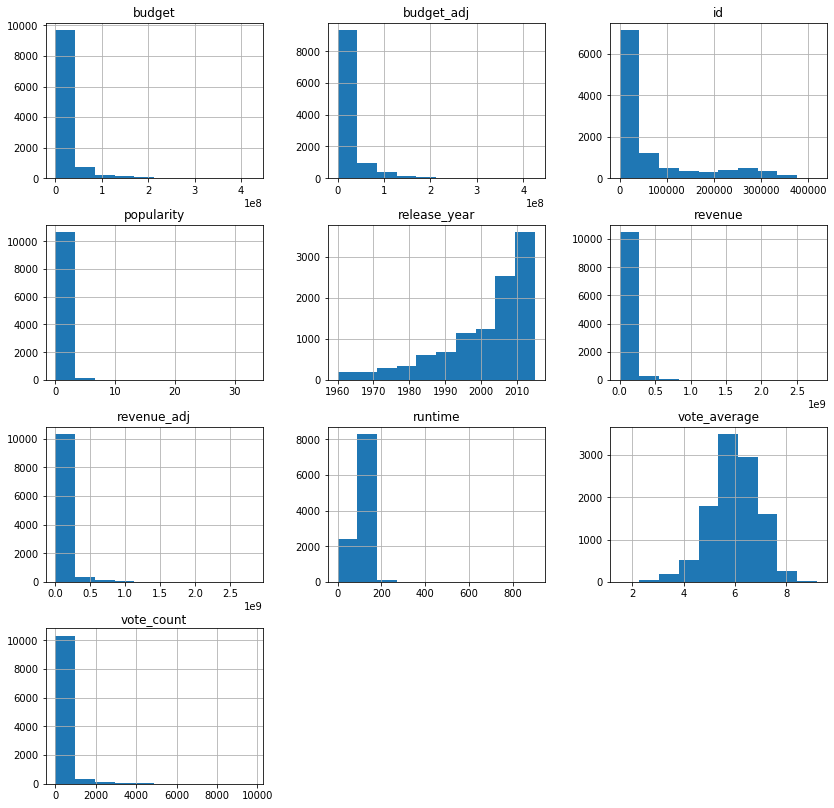

```python
df.hist(figsize=(14,14));
```

### Data Cleaning

Analysing the dataset, it was identified some points to clean. In this section the unnecessary data will be dropped and some values will be cleaned.

#### Dropping Unneeded Properties

The unneeded properties for the analysis that will be dropped are:

- cast
- keywords
- imdb_id
- homepage
- overview
- tagline
- release_date
- runtime

```python
df = df.drop(['cast', 'keywords', 'imdb_id', 'homepage', 'overview', 'release_date', 'tagline', 'runtime'], axis=1)
```

#### Adjusting Values

There are some scientific numbers in the dataset, it will be changed to numeric numbers.

```python
# https://stackoverflow.com/questions/38689125/how-to-get-rid-of-pandas-converting-large-numbers-in-excel-sheet-to-exponential
pd.options.display.float_format = '{:.2f}'.format
```

Analysing the histograms, important columns containing 0 could be seen and in order to realize the analysis it was decided remove the rows that contain 0 in the important columns for analysis.

```python
df['revenue_adj'].replace(0, np.NAN, inplace=True)
df['revenue'].replace(0, np.NAN, inplace=True)
df['budget_adj'].replace(0, np.NAN, inplace=True)
df['budget'].replace(0, np.NAN, inplace=True)

df.dropna(axis=0, inplace=True)
```

#### Splitting Multi Value Properties

There are multi value properties in the dataset and three of then are very important for the analysis. The multi value properties are:

- director
- genres
- production_companies

```python
# The multi values are separated by "|". The code below will be split de multi values to columns.
df_directors = (df['director'].str.split('|', expand=True).rename(columns=lambda x: f"director_{x+1}"))
df_genres = (df['genres'].str.split('|', expand=True).rename(columns=lambda x: f"genre_{x+1}"))
df_companies = (df['production_companies'].str.split('|', expand=True).rename(columns=lambda x: f"production_companie_{x+1}"))

df_directors.head()
```

|  | director_1 | director_2 | director_3 | director_4 | director_5 | director_6 | director_7 | director_8 | director_9 | director_10 | director_11 | director_12 |
| --- | --- | --- | --- | --- | --- | --- | --- | --- | --- | --- | --- | --- |
| 0 | Colin Trevorrow | None | None | None | None | None | None | None | None | None | None | None |
| 1 | George Miller | None | None | None | None | None | None | None | None | None | None | None |
| 2 | Robert Schwentke | None | None | None | None | None | None | None | None | None | None | None |
| 3 | J.J. Abrams | None | None | None | None | None | None | None | None | None | None | None |
| 4 | James Wan | None | None | None | None | None | None | None | None | None | None | None |

The multi value properties were separated in differents dataframes that should be joined to the original dataframe and after that it should be checked. The author chose to keep the first column regarding the director and the production company of the films in order to facilitate the analysis.

```python
# dropping the multi value properties
df = df.drop(['director', 'genres', 'production_companies'], axis=1)

directors = df_directors.iloc[:,0]
companies = df_companies.iloc[:,0]
df = df.join([directors, df_genres, companies])
```

```python
df.info()
```

```
<class 'pandas.core.frame.DataFrame'>
Int64Index: 3808 entries, 0 to 10848
Data columns (total 17 columns):
id                       3808 non-null int64
popularity               3808 non-null float64
budget                   3808 non-null float64
revenue                  3808 non-null float64
original_title           3808 non-null object
vote_count               3808 non-null int64
vote_average             3808 non-null float64
release_year             3808 non-null int64
budget_adj               3808 non-null float64
revenue_adj              3808 non-null float64
director_1               3808 non-null object
genre_1                  3808 non-null object
genre_2                  3171 non-null object
genre_3                  2091 non-null object
genre_4                  864 non-null object
genre_5                  256 non-null object
production_companie_1    3808 non-null object
dtypes: float64(6), int64(3), object(8)
memory usage: 695.5+ KB
```

```python
duplicated = df[df.duplicated(keep='last')]
duplicated.head()
```

|  | id | popularity | budget | revenue | original_title | vote_count | vote_average | release_year | budget_adj | revenue_adj | director_1 | genre_1 | genre_2 | genre_3 | genre_4 | genre_5 | production_companie_1 |
| --- | --- | --- | --- | --- | --- | --- | --- | --- | --- | --- | --- | --- | --- | --- | --- | --- | --- |
| 2089 | 42194 | 0.60 | 30000000.00 | 967000.00 | TEKKEN | 110 | 5.00 | 2010 | 30000000.00 | 967000.00 | Dwight H. Little | Crime | Drama | Action | Thriller | Science Fiction | Namco |

#### Refining The Dataset

In the las section, a duplicity was found and the director and the production company column names were modified. The duplicity will be dropped and the column names will be renamed.

```python
df.drop_duplicates(subset=None, keep='first', inplace=True)
df.duplicated().sum()
```

```
0
```

```python
# whereas the main director and the main production_company are in the top position of the tuple
names = df.columns.tolist()
names[names.index('director_1')] = 'director'
names[names.index('production_companie_1')] = 'production_company'
df.columns = names
df.head()
```

|  | id | popularity | budget | revenue | original_title | vote_count | vote_average | release_year | budget_adj | revenue_adj | director | genre_1 | genre_2 | genre_3 | genre_4 | genre_5 | production_company |
| --- | --- | --- | --- | --- | --- | --- | --- | --- | --- | --- | --- | --- | --- | --- | --- | --- | --- |
| 0 | 135397 | 32.99 | 150000000.00 | 1513528810.00 | Jurassic World | 5562 | 6.50 | 2015 | 137999939.28 | 1392445892.52 | Colin Trevorrow | Action | Adventure | Science Fiction | Thriller | None | Universal Studios |
| 1 | 76341 | 28.42 | 150000000.00 | 378436354.00 | Mad Max: Fury Road | 6185 | 7.10 | 2015 | 137999939.28 | 348161292.49 | George Miller | Action | Adventure | Science Fiction | Thriller | None | Village Roadshow Pictures |
| 2 | 262500 | 13.11 | 110000000.00 | 295238201.00 | Insurgent | 2480 | 6.30 | 2015 | 101199955.47 | 271619025.41 | Robert Schwentke | Adventure | Science Fiction | Thriller | None | None | Summit Entertainment |
| 3 | 140607 | 11.17 | 200000000.00 | 2068178225.00 | Star Wars: The Force Awakens | 5292 | 7.50 | 2015 | 183999919.04 | 1902723129.80 | J.J. Abrams | Action | Adventure | Science Fiction | Fantasy | None | Lucasfilm |
| 4 | 168259 | 9.34 | 190000000.00 | 1506249360.00 | Furious 7 | 2947 | 7.30 | 2015 | 174799923.09 | 1385748801.47 | James Wan | Action | Crime | Thriller | None | None | Universal Pictures |

```python
df.info()
```

```
<class 'pandas.core.frame.DataFrame'>
Int64Index: 3807 entries, 0 to 10848
Data columns (total 17 columns):
id                    3807 non-null int64
popularity            3807 non-null float64
budget                3807 non-null float64
revenue               3807 non-null float64
original_title        3807 non-null object
vote_count            3807 non-null int64
vote_average          3807 non-null float64
release_year          3807 non-null int64
budget_adj            3807 non-null float64
revenue_adj           3807 non-null float64
director              3807 non-null object
genre_1               3807 non-null object
genre_2               3170 non-null object
genre_3               2090 non-null object
genre_4               863 non-null object
genre_5               255 non-null object
production_company    3807 non-null object
dtypes: float64(6), int64(3), object(8)
memory usage: 535.4+ KB
```